# Moving the Needle

A comparison of different policy options to increase COVID-19 vaccination rates

Neel Bhagwat & Jenny Kim

December 13, 2021

# Abstract

This study focuses on the various policies that the US Federal government can enact to increase COVID-19 vaccination rates and stabilize the spread of COVID-19 with herd immunity. It compares a vaccine mandate enforced with a fine, the policy in question, to various incentives such as tax rebates and sporting tickets. It also takes into account the accessibility of vaccination centers, measured by the proximity of vaccination centers from residencies, as well as combinations of these different policy attributes. The target population for this study are all Americans 18 years and older who have not received a dose of a COVID-19 vaccine. Below are lists of all possible values of each attribute included in the choice questions:

- Type of incentives for compliance: grocery store gift cards, internet rebates, sporting tickets, cash
- Value of incentives for compliance ranging from $0-$1000 in increasing increments
- Value of fines for non-compliance ranging from $0-$1000 in increasing increments
- Distance from vaccination centers ranging from 0 miles from residences - 10 miles from residences in increasing increments

The results for our study show a high confidence interval for all attributes, plus a positive coefficient for distance to a vaccination center - our respondents had slightly higher preference towards further vaccination centers, an unlikely and unexpected result. The variance and accuracy of our coefficients reemphasizes that we need a larger and more varied sample to get a more accurate and definite estimate. The positive value for distance to a vaccination center also shows a possible interaction effect with another attribute. This informs us that to get accurate readings, we will need to study both interaction and main effects of attributes. To do so, a full factorial design with every possible choice attribute combination will be the most optimal, and we aim to get a sample size as large as possible by reaching out to others in the GW community and across the US.

# Introduction

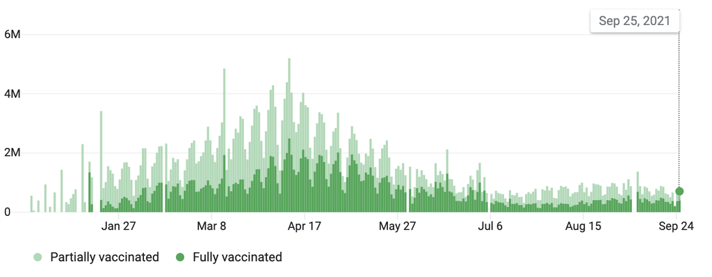

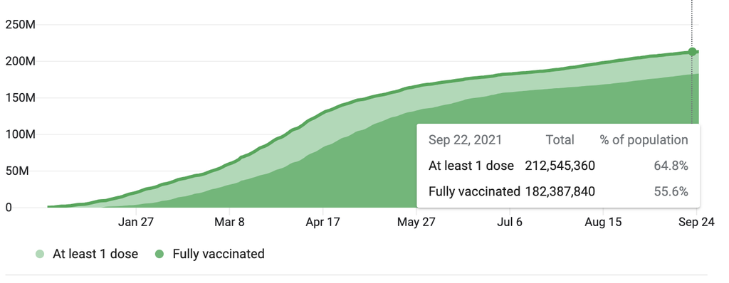

In turn, the Delta variant, a highly-contagious strain of SARS-COV-2, the virus that causes COVID-19, ravaged through unvaccinated populations and caused a surge in cases.

On September 9th, 2021, U.S. President Joe Biden announced vaccine mandates for 100 million Americans, including federal employees and private-sector employees part of firms with over 100 people. This has been met with praise from some experts who claim that forcing Americans to get vaccinated is crucial, criticism from other experts who claim that resistance to vaccine mandates will cause labor shortages and is not effective enough to vaccinate enough of the population [for herd immunity], and hostile resistance, particularly from conservatives, who attack the Constitutional provision of the mandates. View this article to read some of the reactions to Biden’s order.

Vaccine mandates have been touted for months, since the COVID-19 vaccine has become available. But before they were enacted many state and local governments started giving out positive incentives such as money or commodities. All levels of government, from the federal government to local, enacted initiatives to increase access to the vaccine by fighting misinformation and setting up mobile vaccination sites.

Our study analyzes the population and the effectiveness of various policies to increase vaccination rates. Each policy in our study consists of different attributes, which vary across each policy. The goal is to optimize the attributes to get as many people vaccinated as possible. The attributes to be considered are:

### Accessibility

Accessibility refers to the distance which a vaccination clinic would be placed from your home. It varies with 0 (door-door vaccinations) - 10 miles from your residence.

### Incentives

Incentives refers to the type of commodity that would be given out at tax season for being fully vaccinated against COVID-19 by the tax return deadline. It varies by cash tax rebates and cash equivalents (gift cards) redeemable at:

- Grocery stores
- Internet providers
- Professional sporting events

### Incentive Value

Incentive value refers to the value of commodities that would be given out at tax season for being fully vaccinated against COVID-19 by the tax return deadline. It varies by increasing increments from $0 to $1000.

### Penalty

Incentive value refers to the penalty due at tax season for failing to get a being fully vaccinated against COVID-19 by the tax return deadline under a vaccine mandate. It varies by increasing increments from $0 to $1000.

# Survey Design

In order to see what sort of policy would be most appealing to those who are currently unvaccinated, the survey is designed to only collect responses from those who would be able to choose to take the vaccine after seeing the policy options. This consists of adults 18 years or older who have not received any doses of a COVID-19 vaccine. Those under the age of 18 and who have already received a vaccine dose were excluded because they are unable to choose to take the vaccine. This survey is also restricted to United States residents only, as this policy would only be directed towards United States residents.

The survey also collects demographic information relating to age, gender identity, race, income, political affiliation, and geographic location to better inform which policies are most effective for which demographics. Educational material presented to the respondents include information on accessibility, incentives, incentive value, and mandate value, which make up the survey’s attributes.

- Accessibility ranged from 0-10 miles for the distance a vaccination clinic would be placed from a respondent’s home. The accessibility range starts at 0 miles because it is in the most convenient spot possible for a respondent to receive a vaccine, and the range ends at 10 miles because most respondents should have a vaccination location outside of 10 miles from their home.
- Incentive value ranged from $0-$1000 to see if there was a value below $1000 that would sway more people to receive the vaccine. This range stopped at $1000, as anything above that number would most likely be infeasible to implement into a policy.
- Incentives were provided as cash or cash equivalents (gift cards) redeemable at grocery stores, internet providers, and professional sporting events. This range of incentives were chosen as they are items that are necessary and/or popular among the general public.
- Penalties ranged from $0-$1000 to see if there was a value below $1000 that would sway more people to receive the vaccine. This range stopped at $1000, as anything above that number would most likely be infeasible to implement into a policy.

Each respondent receives 10 choice questions that have two options “I will take the vaccine under these conditions” (where the conditions are listed in the option) and “I will not take the vaccine under these conditions”. There is one alternative per choice question (the vaccine conditions) and a no-choice option, where respondents are informed that it means they would not take the vaccine under the conditions listed in the first alternative. An example figure of a random conjoint question can be seen below.

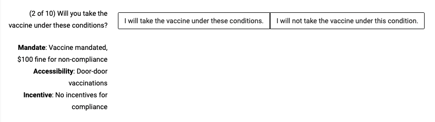

# Data Analysis

### Sample Description

The final pilot survey sample after cleaning consists of 107 respondents. The choice data sheet contains of 20 rows per respondent, denoting 2 alternatives per question (will you take the vaccine under this condition or not?) and 10 questions each.

### Data Cleaning

When we first opened the responses from the three separate components, we noticed a lot of null values to numerous attributes, including session ids that seemed to be from unsuccessful attempts to view our survey, or from bots on the internet. To remove these values gracefully, we had to join these three components together by the session id, a unique identifier for each participant associated with the survey. To do so, we took out duplicate columns and removed null values for session. We also computed the time took to complete each survey component in unique columns. Then, we filtered out respondents that did not answer the choice questions and did not meet eligibility criteria. We only filtered out respondents based on if they didn’t answer any choice questions because no one only partially answered th choice questions, so we could filter out only those who didn’t answer any. There were 697 total respondents, but we trimmed it down to 107 because many did not meet the eligibility criteria and were not able to get to the choice questions. We also filtered out respondents who didn’t pass the attention check, but no one was filtered out in this process as every respondent passed.

### Modeling

Using the model and the choice data, we then ran the logitr model using preference space to estimate the beta coefficients. Running a summary of the results returned to us the estimated coefficients and the standard error.

|  | x |
| --- | --- |
| value | 0.0005111 |
| penalty | -0.0004686 |
| accessibility_1 | 0.0804890 |
| accessibility_3 | 0.0735859 |
| accessibility_10 | 0.0285740 |
| incentive_grocery_store | 0.5278555 |
| incentive_internet | 0.1210913 |
| incentive_sport_tickets | 0.0098003 |
| outsideGood | 0.9830817 |

```
kable(se(model))
```

[output not shown]

[output not shown]

|  | x |
| --- | --- |
| value | 0.0007494 |
| penalty | -0.0007930 |
| accessibility_1 | -0.3628354 |
| accessibility_3 | -0.5992260 |
| accessibility_10 | -0.3049389 |
| incentive_grocery_store | 0.8077133 |
| incentive_internet | -0.2547931 |
| incentive_sport_tickets | 0.3149509 |
| outsideGood | 0.4124942 |
| value_liberal | 0.0000072 |
| penalty_liberal | 0.0005274 |
| accessibility_1_liberal | 0.5646333 |
| accessibility_3_liberal | 0.8355463 |
| accessibility_10_liberal | 0.4735110 |
| incentive_grocery_store_liberal | -0.3286184 |
| incentive_internet_liberal | -0.0561608 |
| incentive_sport_tickets_liberal | -0.3111666 |
| outsideGood_liberal | -0.2461253 |
| value_conservative | 0.0002351 |
| penalty_conservative | 0.0004864 |
| accessibility_1_conservative | 0.9932580 |
| accessibility_3_conservative | 1.1545165 |
| accessibility_10_conservative | 0.5914997 |
| incentive_grocery_store_conservative | -1.1227352 |
| incentive_internet_conservative | 0.6716591 |
| incentive_sport_tickets_conservative | -0.8618877 |
| outsideGood_conservative | 2.0021718 |
| value_independent | -0.0006199 |
| penalty_independent | 0.0006692 |
| accessibility_1_independent | 0.3203842 |
| accessibility_3_independent | 0.9647243 |
| accessibility_10_independent | -0.1226066 |
| incentive_grocery_store_independent | -0.2292768 |
| incentive_internet_independent | 0.8813157 |
| incentive_sport_tickets_independent | 0.0599380 |
| outsideGood_independent | 1.0120944 |

|  | x |
| --- | --- |
| value | 0.0004551 |
| penalty | 0.0005237 |
| accessibility_1 | 0.3043856 |
| accessibility_3 | 0.3218997 |
| accessibility_10 | 0.3573930 |
| incentive_grocery_store | 0.3839628 |
| incentive_internet | 0.4246870 |
| incentive_sport_tickets | 0.4401965 |
| outsideGood | 0.3951194 |
| value_liberal | 0.0005852 |
| penalty_liberal | 0.0006997 |
| accessibility_1_liberal | 0.2949376 |
| accessibility_3_liberal | 0.2894474 |
| accessibility_10_liberal | 0.4454765 |
| incentive_grocery_store_liberal | 0.5213877 |
| incentive_internet_liberal | 0.5525032 |
| incentive_sport_tickets_liberal | 0.5638608 |
| outsideGood_liberal | 0.4944326 |
| value_conservative | 0.0006199 |
| penalty_conservative | 0.0007465 |
| accessibility_1_conservative | 0.5398139 |
| accessibility_3_conservative | 0.5475154 |
| accessibility_10_conservative | 0.6041454 |
| incentive_grocery_store_conservative | 0.5906551 |
| incentive_internet_conservative | 0.5821913 |
| incentive_sport_tickets_conservative | 0.6382369 |
| outsideGood_conservative | 0.6260375 |
| value_independent | 0.0006589 |
| penalty_independent | 0.0007991 |
| accessibility_1_independent | 0.5878214 |
| accessibility_3_independent | 0.5580106 |
| accessibility_10_independent | 0.6310279 |
| incentive_grocery_store_independent | 0.6019469 |
| incentive_internet_independent | 0.6527790 |
| incentive_sport_tickets_independent | 0.6483903 |
| outsideGood_independent | 0.6364934 |

|  | x |
| --- | --- |
| value | 0.0003445 |
| penalty | -0.0011474 |
| accessibility_1 | 0.1270044 |
| accessibility_3 | 0.1178104 |
| accessibility_10 | -0.3246856 |
| incentive_grocery_store | 0.4872539 |
| incentive_internet | 0.1613869 |
| incentive_sport_tickets | 0.0789400 |
| outsideGood | 0.8599015 |
| value_low | 0.0004641 |
| penalty_low | 0.0008499 |
| accessibility_1_low | -0.0020351 |
| accessibility_3_low | -0.0912626 |
| accessibility_10_low | 0.1989877 |
| incentive_grocery_store_low | -0.0453873 |
| incentive_internet_low | 0.1695055 |
| incentive_sport_tickets_low | -0.1603067 |
| outsideGood_low | 0.3508514 |
| value_high | 0.0000381 |
| penalty_high | 0.0016762 |
| accessibility_1_high | -0.1538972 |
| accessibility_3_high | 0.0323651 |
| accessibility_10_high | 1.1737559 |
| incentive_grocery_store_high | 0.2786345 |
| incentive_internet_high | -0.4680978 |
| incentive_sport_tickets_high | 0.0701226 |
| outsideGood_high | 0.0912208 |

|  | x |
| --- | --- |
| value | 0.0003284 |
| penalty | 0.0004240 |
| accessibility_1 | 0.3110987 |
| accessibility_3 | 0.3158577 |
| accessibility_10 | 0.3188004 |
| incentive_grocery_store | 0.3073506 |
| incentive_internet | 0.3248201 |
| incentive_sport_tickets | 0.3210829 |
| outsideGood | 0.3192067 |
| value_low | 0.0004380 |
| penalty_low | 0.0005801 |
| accessibility_1_low | 0.4253876 |
| accessibility_3_low | 0.4260864 |
| accessibility_10_low | 0.4409104 |
| incentive_grocery_store_low | 0.4235103 |
| incentive_internet_low | 0.4422044 |
| incentive_sport_tickets_low | 0.4435092 |
| outsideGood_low | 0.4493175 |
| value_high | 0.0005521 |
| penalty_high | 0.0006664 |
| accessibility_1_high | 0.5100550 |
| accessibility_3_high | 0.5017537 |
| accessibility_10_high | 0.5074341 |
| incentive_grocery_store_high | 0.4880623 |
| incentive_internet_high | 0.5299878 |
| incentive_sport_tickets_high | 0.5312624 |
| outsideGood_high | 0.5413572 |

|  | x |
| --- | --- |
| value | 0.0005767 |
| penalty | -0.0003769 |
| accessibility_1 | 0.1493537 |
| accessibility_3 | 0.0995948 |
| accessibility_10 | 0.0911452 |
| incentive_grocery_store | 0.2767176 |
| incentive_internet | 0.1446156 |
| incentive_sport_tickets | -0.0048925 |
| outsideGood | 1.1936386 |
| value_asian | -0.0004947 |
| penalty_asian | -0.0015811 |
| accessibility_1_asian | 0.1329034 |
| accessibility_3_asian | -1.1830281 |
| accessibility_10_asian | -1.0854955 |
| incentive_grocery_store_asian | 0.1798753 |
| incentive_internet_asian | -0.4854084 |
| incentive_sport_tickets_asian | -1.4625230 |
| outsideGood_asian | -3.3031581 |
| value_black | -0.0009031 |
| penalty_black | 0.0003545 |
| accessibility_1_black | -0.0174029 |
| accessibility_3_black | 0.1345240 |
| accessibility_10_black | 0.6291846 |
| incentive_grocery_store_black | 0.3805330 |
| incentive_internet_black | -0.6688335 |
| incentive_sport_tickets_black | 0.3029948 |
| outsideGood_black | -0.9511424 |
| value_hispanic | -0.0003316 |
| penalty_hispanic | -0.0003742 |
| accessibility_1_hispanic | -1.1800256 |
| accessibility_3_hispanic | 0.4838921 |
| accessibility_10_hispanic | -0.9817333 |
| incentive_grocery_store_hispanic | 1.7012276 |
| incentive_internet_hispanic | 2.1524001 |
| incentive_sport_tickets_hispanic | 2.2733010 |
| outsideGood_hispanic | 1.4130574 |
| value_native | 0.0010442 |
| penalty_native | -0.0015685 |
| accessibility_1_native | 0.2819474 |
| accessibility_3_native | 0.9975117 |
| accessibility_10_native | -0.0405203 |
| incentive_grocery_store_native | 2.0041884 |
| incentive_internet_native | 0.0333943 |
| incentive_sport_tickets_native | -0.8685169 |
| outsideGood_native | 0.0937451 |

|  | x |
| --- | --- |
| value | 0.0002245 |
| penalty | 0.0002816 |
| accessibility_1 | 0.2193722 |
| accessibility_3 | 0.2187689 |
| accessibility_10 | 0.2200292 |
| incentive_grocery_store | 0.2149491 |
| incentive_internet | 0.2193150 |
| incentive_sport_tickets | 0.2229741 |
| outsideGood | 0.2317993 |
| value_asian | 0.0010520 |
| penalty_asian | 0.0013554 |
| accessibility_1_asian | 1.0890372 |
| accessibility_3_asian | 0.9494852 |
| accessibility_10_asian | 1.0216612 |
| incentive_grocery_store_asian | 1.1495492 |
| incentive_internet_asian | 1.2041302 |
| incentive_sport_tickets_asian | 1.1761442 |
| outsideGood_asian | 1.3543555 |
| value_black | 0.0006619 |
| penalty_black | 0.0009126 |
| accessibility_1_black | 0.6797840 |
| accessibility_3_black | 0.6524295 |
| accessibility_10_black | 0.6686678 |
| incentive_grocery_store_black | 0.6223760 |
| incentive_internet_black | 0.6939441 |
| incentive_sport_tickets_black | 0.6753842 |
| outsideGood_black | 0.6886401 |
| value_hispanic | 0.0011081 |
| penalty_hispanic | 0.0013126 |
| accessibility_1_hispanic | 1.0119626 |
| accessibility_3_hispanic | 0.8717907 |
| accessibility_10_hispanic | 1.0262839 |
| incentive_grocery_store_hispanic | 1.1957915 |
| incentive_internet_hispanic | 1.2885827 |
| incentive_sport_tickets_hispanic | 1.2897061 |
| outsideGood_hispanic | 1.2391928 |
| value_native | 0.0015067 |
| penalty_native | 0.0017405 |
| accessibility_1_native | 1.6091822 |
| accessibility_3_native | 1.3592319 |
| accessibility_10_native | 1.4966115 |
| incentive_grocery_store_native | 1.4367922 |
| incentive_internet_native | 1.2694133 |
| incentive_sport_tickets_native | 1.6821636 |
| outsideGood_native | 1.4531344 |

|  | x |
| --- | --- |
| value | 0.0003598 |
| penalty | -0.0006134 |
| accessibility_1 | 0.0661708 |
| accessibility_3 | -0.2540634 |
| accessibility_10 | 0.0879980 |
| incentive_grocery_store | 0.5380771 |
| incentive_internet | -0.2216536 |
| incentive_sport_tickets | 0.2010983 |
| outsideGood | 0.6532283 |
| value_low | 0.0002229 |
| penalty_low | 0.0001824 |
| accessibility_1_low | -0.0243030 |
| accessibility_3_low | 0.5894149 |
| accessibility_10_low | -0.1382827 |
| incentive_grocery_store_low | -0.0633475 |
| incentive_internet_low | 0.5188284 |
| incentive_sport_tickets_low | -0.2295321 |
| outsideGood_low | 0.6198316 |
| value_high | 0.0009449 |
| penalty_high | 0.0008621 |
| accessibility_1_high | 0.6248925 |
| accessibility_3_high | 0.5401381 |
| accessibility_10_high | 0.3625476 |
| incentive_grocery_store_high | 0.3688962 |
| incentive_internet_high | 0.9575404 |
| incentive_sport_tickets_high | -0.4836343 |
| outsideGood_high | 0.8185979 |

|  | x |
| --- | --- |
| value | 0.0003061 |
| penalty | 0.0004300 |
| accessibility_1 | 0.2910949 |
| accessibility_3 | 0.3101552 |
| accessibility_10 | 0.2833100 |
| incentive_grocery_store | 0.2824072 |
| incentive_internet | 0.3118029 |
| incentive_sport_tickets | 0.3028663 |
| outsideGood | 0.3033357 |
| value_low | 0.0004043 |
| penalty_low | 0.0005356 |
| accessibility_1_low | 0.3956180 |
| accessibility_3_low | 0.3998634 |
| accessibility_10_low | 0.3944497 |
| incentive_grocery_store_low | 0.3812181 |
| incentive_internet_low | 0.4099136 |
| incentive_sport_tickets_low | 0.4066200 |
| outsideGood_low | 0.4137962 |
| value_high | 0.0008768 |
| penalty_high | 0.0009951 |
| accessibility_1_high | 0.7343250 |
| accessibility_3_high | 0.7455972 |
| accessibility_10_high | 0.7819365 |
| incentive_grocery_store_high | 0.7716949 |
| incentive_internet_high | 0.8025723 |
| incentive_sport_tickets_high | 0.8633954 |
| outsideGood_high | 0.8737230 |

# Results

|  | x |
| --- | --- |
| value | 0.0005111 |
| penalty | -0.0004686 |
| accessibility_1 | 0.0804890 |
| accessibility_3 | 0.0735859 |
| accessibility_10 | 0.0285740 |
| incentive_grocery_store | 0.5278555 |
| incentive_internet | 0.1210913 |
| incentive_sport_tickets | 0.0098003 |
| outsideGood | 0.9830817 |

|  | x |
| --- | --- |
| value | 0.0001911 |
| penalty | 0.0002416 |
| accessibility_1 | 0.1857847 |
| accessibility_3 | 0.1837196 |
| accessibility_10 | 0.1868493 |
| incentive_grocery_store | 0.1803210 |
| incentive_internet | 0.1912552 |
| incentive_sport_tickets | 0.1928311 |
| outsideGood | 0.1963739 |

|  | x |
| --- | --- |
| value | 0.0007100 |
| penalty | -0.0004837 |
| accessibility_1 | 0.1958957 |
| accessibility_3 | 0.0587616 |
| accessibility_10 | 0.1885783 |
| incentive_grocery_store | 0.5945227 |
| incentive_internet | 0.1087567 |
| incentive_sport_tickets | 0.2330551 |
| outsideGood | 0.4305177 |
| outsideGood_resistant | 0.9852725 |
| value_resistant | -0.0003627 |
| penalty_resistant | -0.0002322 |
| accessibility_1_resistant | -0.3975556 |
| accessibility_3_resistant | -0.0384331 |
| accessibility_10_resistant | -0.3220526 |
| incentive_grocery_store_resistant | -0.1738697 |
| incentive_internet_resistant | -0.1735595 |
| incentive_sport_tickets_resistant | -0.2535831 |

|  | x |
| --- | --- |
| value | 0.0002828 |
| penalty | 0.0003302 |
| accessibility_1 | 0.2670157 |
| accessibility_3 | 0.2653845 |
| accessibility_10 | 0.2714119 |
| incentive_grocery_store | 0.2620557 |
| incentive_internet | 0.2655115 |
| incentive_sport_tickets | 0.2847370 |
| outsideGood | 0.2766491 |
| outsideGood_resistant | 0.4126940 |
| value_resistant | 0.0004121 |
| penalty_resistant | 0.0005347 |
| accessibility_1_resistant | 0.4015675 |
| accessibility_3_resistant | 0.3870407 |
| accessibility_10_resistant | 0.3963647 |
| incentive_grocery_store_resistant | 0.3832617 |
| incentive_internet_resistant | 0.4140298 |
| incentive_sport_tickets_resistant | 0.4106109 |

|  | x |
| --- | --- |
| value | 0.0007494 |
| penalty | -0.0007930 |
| accessibility_1 | -0.3628354 |
| accessibility_3 | -0.5992260 |
| accessibility_10 | -0.3049389 |
| incentive_grocery_store | 0.8077133 |
| incentive_internet | -0.2547931 |
| incentive_sport_tickets | 0.3149509 |
| outsideGood | 0.4124942 |
| value_liberal | 0.0000072 |
| penalty_liberal | 0.0005274 |
| accessibility_1_liberal | 0.5646333 |
| accessibility_3_liberal | 0.8355463 |
| accessibility_10_liberal | 0.4735110 |
| incentive_grocery_store_liberal | -0.3286184 |
| incentive_internet_liberal | -0.0561608 |
| incentive_sport_tickets_liberal | -0.3111666 |
| outsideGood_liberal | -0.2461253 |
| value_conservative | 0.0002351 |
| penalty_conservative | 0.0004864 |
| accessibility_1_conservative | 0.9932580 |
| accessibility_3_conservative | 1.1545165 |
| accessibility_10_conservative | 0.5914997 |
| incentive_grocery_store_conservative | -1.1227352 |
| incentive_internet_conservative | 0.6716591 |
| incentive_sport_tickets_conservative | -0.8618877 |
| outsideGood_conservative | 2.0021718 |
| value_independent | -0.0006199 |
| penalty_independent | 0.0006692 |
| accessibility_1_independent | 0.3203842 |
| accessibility_3_independent | 0.9647243 |
| accessibility_10_independent | -0.1226066 |
| incentive_grocery_store_independent | -0.2292768 |
| incentive_internet_independent | 0.8813157 |
| incentive_sport_tickets_independent | 0.0599380 |
| outsideGood_independent | 1.0120944 |

|  | x |
| --- | --- |
| value | 0.0004551 |
| penalty | 0.0005237 |
| accessibility_1 | 0.3043856 |
| accessibility_3 | 0.3218997 |
| accessibility_10 | 0.3573930 |
| incentive_grocery_store | 0.3839628 |
| incentive_internet | 0.4246870 |
| incentive_sport_tickets | 0.4401965 |
| outsideGood | 0.3951194 |
| value_liberal | 0.0005852 |
| penalty_liberal | 0.0006997 |
| accessibility_1_liberal | 0.2949376 |
| accessibility_3_liberal | 0.2894474 |
| accessibility_10_liberal | 0.4454765 |
| incentive_grocery_store_liberal | 0.5213877 |
| incentive_internet_liberal | 0.5525032 |
| incentive_sport_tickets_liberal | 0.5638608 |
| outsideGood_liberal | 0.4944326 |
| value_conservative | 0.0006199 |
| penalty_conservative | 0.0007465 |
| accessibility_1_conservative | 0.5398139 |
| accessibility_3_conservative | 0.5475154 |
| accessibility_10_conservative | 0.6041454 |
| incentive_grocery_store_conservative | 0.5906551 |
| incentive_internet_conservative | 0.5821913 |
| incentive_sport_tickets_conservative | 0.6382369 |
| outsideGood_conservative | 0.6260375 |
| value_independent | 0.0006589 |
| penalty_independent | 0.0007991 |
| accessibility_1_independent | 0.5878214 |
| accessibility_3_independent | 0.5580106 |
| accessibility_10_independent | 0.6310279 |
| incentive_grocery_store_independent | 0.6019469 |
| incentive_internet_independent | 0.6527790 |
| incentive_sport_tickets_independent | 0.6483903 |
| outsideGood_independent | 0.6364934 |

|  | x |
| --- | --- |
| value | 0.0003445 |
| penalty | -0.0011474 |
| accessibility_1 | 0.1270044 |
| accessibility_3 | 0.1178104 |
| accessibility_10 | -0.3246856 |
| incentive_grocery_store | 0.4872539 |
| incentive_internet | 0.1613869 |
| incentive_sport_tickets | 0.0789400 |
| outsideGood | 0.8599015 |
| value_low | 0.0004641 |
| penalty_low | 0.0008499 |
| accessibility_1_low | -0.0020351 |
| accessibility_3_low | -0.0912626 |
| accessibility_10_low | 0.1989877 |
| incentive_grocery_store_low | -0.0453873 |
| incentive_internet_low | 0.1695055 |
| incentive_sport_tickets_low | -0.1603067 |
| outsideGood_low | 0.3508514 |
| value_high | 0.0000381 |
| penalty_high | 0.0016762 |
| accessibility_1_high | -0.1538972 |
| accessibility_3_high | 0.0323651 |
| accessibility_10_high | 1.1737559 |
| incentive_grocery_store_high | 0.2786345 |
| incentive_internet_high | -0.4680978 |
| incentive_sport_tickets_high | 0.0701226 |
| outsideGood_high | 0.0912208 |

|  | x |
| --- | --- |
| value | 0.0003284 |
| penalty | 0.0004240 |
| accessibility_1 | 0.3110987 |
| accessibility_3 | 0.3158577 |
| accessibility_10 | 0.3188004 |
| incentive_grocery_store | 0.3073506 |
| incentive_internet | 0.3248201 |
| incentive_sport_tickets | 0.3210829 |
| outsideGood | 0.3192067 |
| value_low | 0.0004380 |
| penalty_low | 0.0005801 |
| accessibility_1_low | 0.4253876 |
| accessibility_3_low | 0.4260864 |
| accessibility_10_low | 0.4409104 |
| incentive_grocery_store_low | 0.4235103 |
| incentive_internet_low | 0.4422044 |
| incentive_sport_tickets_low | 0.4435092 |
| outsideGood_low | 0.4493175 |
| value_high | 0.0005521 |
| penalty_high | 0.0006664 |
| accessibility_1_high | 0.5100550 |
| accessibility_3_high | 0.5017537 |
| accessibility_10_high | 0.5074341 |
| incentive_grocery_store_high | 0.4880623 |
| incentive_internet_high | 0.5299878 |
| incentive_sport_tickets_high | 0.5312624 |
| outsideGood_high | 0.5413572 |

|  | x |
| --- | --- |
| value | 0.0005767 |
| penalty | -0.0003769 |
| accessibility_1 | 0.1493537 |
| accessibility_3 | 0.0995948 |
| accessibility_10 | 0.0911452 |
| incentive_grocery_store | 0.2767176 |
| incentive_internet | 0.1446156 |
| incentive_sport_tickets | -0.0048925 |
| outsideGood | 1.1936386 |
| value_asian | -0.0004947 |
| penalty_asian | -0.0015811 |
| accessibility_1_asian | 0.1329034 |
| accessibility_3_asian | -1.1830281 |
| accessibility_10_asian | -1.0854955 |
| incentive_grocery_store_asian | 0.1798753 |
| incentive_internet_asian | -0.4854084 |
| incentive_sport_tickets_asian | -1.4625230 |
| outsideGood_asian | -3.3031581 |
| value_black | -0.0009031 |
| penalty_black | 0.0003545 |
| accessibility_1_black | -0.0174029 |
| accessibility_3_black | 0.1345240 |
| accessibility_10_black | 0.6291846 |
| incentive_grocery_store_black | 0.3805330 |
| incentive_internet_black | -0.6688335 |
| incentive_sport_tickets_black | 0.3029948 |
| outsideGood_black | -0.9511424 |
| value_hispanic | -0.0003316 |
| penalty_hispanic | -0.0003742 |
| accessibility_1_hispanic | -1.1800256 |
| accessibility_3_hispanic | 0.4838921 |
| accessibility_10_hispanic | -0.9817333 |
| incentive_grocery_store_hispanic | 1.7012276 |
| incentive_internet_hispanic | 2.1524001 |
| incentive_sport_tickets_hispanic | 2.2733010 |
| outsideGood_hispanic | 1.4130574 |
| value_native | 0.0010442 |
| penalty_native | -0.0015685 |
| accessibility_1_native | 0.2819474 |
| accessibility_3_native | 0.9975117 |
| accessibility_10_native | -0.0405203 |
| incentive_grocery_store_native | 2.0041884 |
| incentive_internet_native | 0.0333943 |
| incentive_sport_tickets_native | -0.8685169 |
| outsideGood_native | 0.0937451 |

|  | x |
| --- | --- |
| value | 0.0002245 |
| penalty | 0.0002816 |
| accessibility_1 | 0.2193722 |
| accessibility_3 | 0.2187689 |
| accessibility_10 | 0.2200292 |
| incentive_grocery_store | 0.2149491 |
| incentive_internet | 0.2193150 |
| incentive_sport_tickets | 0.2229741 |
| outsideGood | 0.2317993 |
| value_asian | 0.0010520 |
| penalty_asian | 0.0013554 |
| accessibility_1_asian | 1.0890372 |
| accessibility_3_asian | 0.9494852 |
| accessibility_10_asian | 1.0216612 |
| incentive_grocery_store_asian | 1.1495492 |
| incentive_internet_asian | 1.2041302 |
| incentive_sport_tickets_asian | 1.1761442 |
| outsideGood_asian | 1.3543555 |
| value_black | 0.0006619 |
| penalty_black | 0.0009126 |
| accessibility_1_black | 0.6797840 |
| accessibility_3_black | 0.6524295 |
| accessibility_10_black | 0.6686678 |
| incentive_grocery_store_black | 0.6223760 |
| incentive_internet_black | 0.6939441 |
| incentive_sport_tickets_black | 0.6753842 |
| outsideGood_black | 0.6886401 |
| value_hispanic | 0.0011081 |
| penalty_hispanic | 0.0013126 |
| accessibility_1_hispanic | 1.0119626 |
| accessibility_3_hispanic | 0.8717907 |
| accessibility_10_hispanic | 1.0262839 |
| incentive_grocery_store_hispanic | 1.1957915 |
| incentive_internet_hispanic | 1.2885827 |
| incentive_sport_tickets_hispanic | 1.2897061 |
| outsideGood_hispanic | 1.2391928 |
| value_native | 0.0015067 |
| penalty_native | 0.0017405 |
| accessibility_1_native | 1.6091822 |
| accessibility_3_native | 1.3592319 |
| accessibility_10_native | 1.4966115 |
| incentive_grocery_store_native | 1.4367922 |
| incentive_internet_native | 1.2694133 |
| incentive_sport_tickets_native | 1.6821636 |
| outsideGood_native | 1.4531344 |

|  | x |
| --- | --- |
| value | 0.0003598 |
| penalty | -0.0006134 |
| accessibility_1 | 0.0661708 |
| accessibility_3 | -0.2540634 |
| accessibility_10 | 0.0879980 |
| incentive_grocery_store | 0.5380771 |
| incentive_internet | -0.2216536 |
| incentive_sport_tickets | 0.2010983 |
| outsideGood | 0.6532283 |
| value_low | 0.0002229 |
| penalty_low | 0.0001824 |
| accessibility_1_low | -0.0243030 |
| accessibility_3_low | 0.5894149 |
| accessibility_10_low | -0.1382827 |
| incentive_grocery_store_low | -0.0633475 |
| incentive_internet_low | 0.5188284 |
| incentive_sport_tickets_low | -0.2295321 |
| outsideGood_low | 0.6198316 |
| value_high | 0.0009449 |
| penalty_high | 0.0008621 |
| accessibility_1_high | 0.6248925 |
| accessibility_3_high | 0.5401381 |
| accessibility_10_high | 0.3625476 |
| incentive_grocery_store_high | 0.3688962 |
| incentive_internet_high | 0.9575404 |
| incentive_sport_tickets_high | -0.4836343 |
| outsideGood_high | 0.8185979 |

|  | x |
| --- | --- |
| value | 0.0003061 |
| penalty | 0.0004300 |
| accessibility_1 | 0.2910949 |
| accessibility_3 | 0.3101552 |
| accessibility_10 | 0.2833100 |
| incentive_grocery_store | 0.2824072 |
| incentive_internet | 0.3118029 |
| incentive_sport_tickets | 0.3028663 |
| outsideGood | 0.3033357 |
| value_low | 0.0004043 |
| penalty_low | 0.0005356 |
| accessibility_1_low | 0.3956180 |
| accessibility_3_low | 0.3998634 |
| accessibility_10_low | 0.3944497 |
| incentive_grocery_store_low | 0.3812181 |
| incentive_internet_low | 0.4099136 |
| incentive_sport_tickets_low | 0.4066200 |
| outsideGood_low | 0.4137962 |
| value_high | 0.0008768 |
| penalty_high | 0.0009951 |
| accessibility_1_high | 0.7343250 |
| accessibility_3_high | 0.7455972 |
| accessibility_10_high | 0.7819365 |
| incentive_grocery_store_high | 0.7716949 |
| incentive_internet_high | 0.8025723 |
| incentive_sport_tickets_high | 0.8633954 |
| outsideGood_high | 0.8737230 |

[output not shown]

[output not shown]